# Breast Cancer Analysis

Me

5/25/2017

## Data Exploration

The following chunk downloads and reads the data, then changes the names to sensible ones. The top 6 rows are then printed.

```r
library(dplyr); library(ggplot2)
url <- "https://archive.ics.uci.edu/ml/machine-learning-databases/breast-cancer-wisconsin/breast-cancer-wisconsin.data"
download.file(url = url, destfile = "./breastcancerdata.csv")
cancer.data <- read.csv("./breastcancerdata.csv")
names(cancer.data) <- c("Sample.code","Clump.Thickness", "Cell.Size.Unif","Cell.Shape.Unif",
                        "Marginal.Adhesion","Epit.Cell.Size","Bare.Nuclei","BlandChrom",
                        "NormalNucleoli","Mitoses", "Class")
head(cancer.data)
```

```
##   Sample.code Clump.Thickness Cell.Size.Unif Cell.Shape.Unif
## 1     1002945               5              4               4
## 2     1015425               3              1               1
## 3     1016277               6              8               8
## 4     1017023               4              1               1
## 5     1017122               8             10              10
## 6     1018099               1              1               1
##   Marginal.Adhesion Epit.Cell.Size Bare.Nuclei BlandChrom NormalNucleoli
## 1                 5              7          10          3              2
## 2                 1              2           2          3              1
## 3                 1              3           4          3              7
## 4                 3              2           1          3              1
## 5                 8              7          10          9              7
## 6                 1              2          10          3              1
##   Mitoses Class
## 1       1     2
## 2       1     2
## 3       1     2
## 4       1     2
## 5       1     4
## 6       1     2
```

I also added a column to clarify malignant v. benign and got rid of a couple of columns, then made the added column into a factor variable.

```r
cancer.data <- cancer.data %>%
  mutate(Class.Name = ifelse( Class == 2, "Benign", "Malignant")) %>%
  select(2:10,12)
cancer.data$Class.Name <- factor(cancer.data$Class.Name)
```

Now then, let’s look at some summary statistics

```r
summary(cancer.data)
```

```
##  Clump.Thickness  Cell.Size.Unif   Cell.Shape.Unif  Marginal.Adhesion
##  Min.   : 1.000   Min.   : 1.000   Min.   : 1.000   Min.   : 1.000
##  1st Qu.: 2.000   1st Qu.: 1.000   1st Qu.: 1.000   1st Qu.: 1.000
##  Median : 4.000   Median : 1.000   Median : 1.000   Median : 1.000
##  Mean   : 4.417   Mean   : 3.138   Mean   : 3.211   Mean   : 2.809
##  3rd Qu.: 6.000   3rd Qu.: 5.000   3rd Qu.: 5.000   3rd Qu.: 4.000
##  Max.   :10.000   Max.   :10.000   Max.   :10.000   Max.   :10.000
##
##  Epit.Cell.Size    Bare.Nuclei    BlandChrom     NormalNucleoli
##  Min.   : 1.000   1      :401   Min.   : 1.000   Min.   : 1.00
##  1st Qu.: 2.000   10     :132   1st Qu.: 2.000   1st Qu.: 1.00
##  Median : 2.000   2      : 30   Median : 3.000   Median : 1.00
##  Mean   : 3.218   5      : 30   Mean   : 3.438   Mean   : 2.87
##  3rd Qu.: 4.000   3      : 28   3rd Qu.: 5.000   3rd Qu.: 4.00
##  Max.   :10.000   8      : 21   Max.   :10.000   Max.   :10.00
##                   (Other): 56
##     Mitoses          Class.Name
##  Min.   : 1.00   Benign   :457
##  1st Qu.: 1.00   Malignant:241
##  Median : 1.00
##  Mean   : 1.59
##  3rd Qu.: 1.00
##  Max.   :10.00
##
```

## Short Analysis

I’m going to go for low-hanging fruit and look at just one of the predictors, clump thickness. So I’ll squish down my columns even more:

```r
cancer.data <- select(cancer.data, Clump.Thickness, Class.Name)
```

What sort of effect may be going on? Let’s make a boxplot to find out:

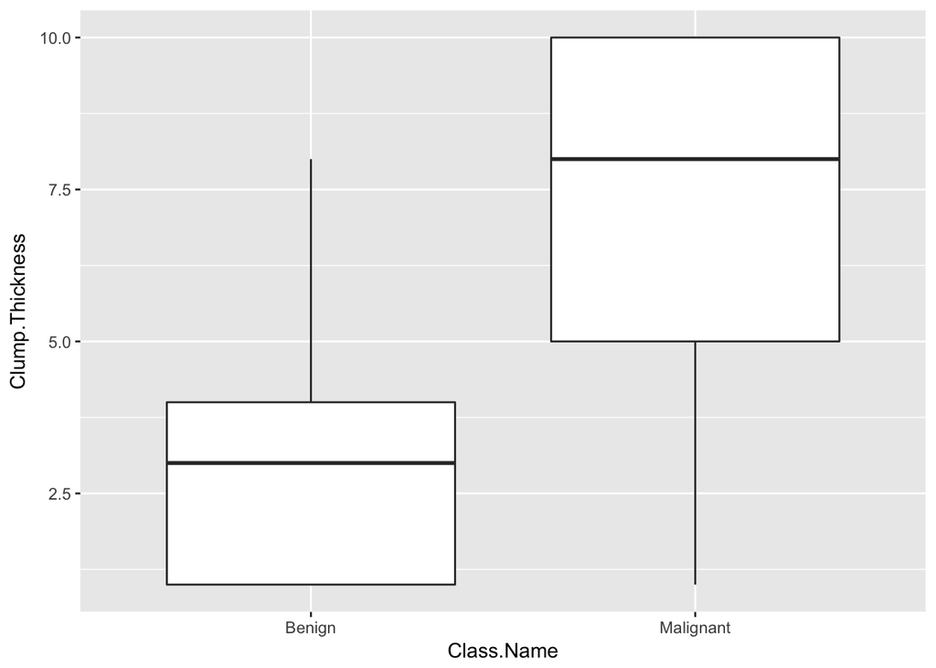

```r
g <- ggplot(cancer.data, aes(Class.Name, Clump.Thickness))
g + geom_boxplot()
```

Looks like a definite difference; let’s make histogram to illustrate it differently:

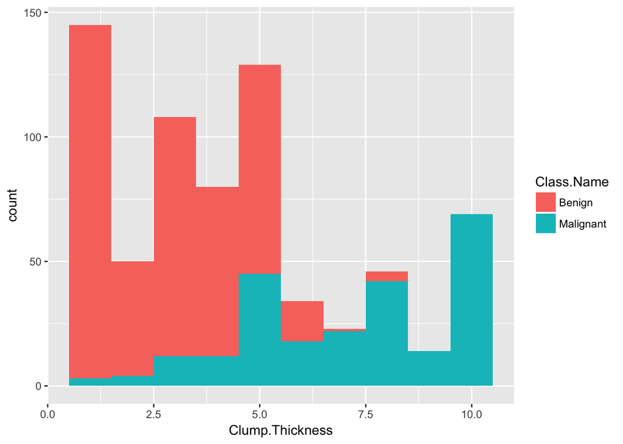

```r
g <- ggplot(cancer.data, aes(Clump.Thickness))
g + geom_histogram(aes(fill = Class.Name), bins = 10)
```

Just for fun, I’m also going to build a quick decision tree:

```r
library(rpart)

fit <- rpart(Class.Name ~ Clump.Thickness, method = "class", data = cancer.data)
summary(fit)
```

```
## Call:
## rpart(formula = Class.Name ~ Clump.Thickness, data = cancer.data,
##     method = "class")
##   n= 698
##
##          CP nsplit rel error    xerror       xstd
## 1 0.5892116      0 1.0000000 1.0000000 0.05212210
## 2 0.0100000      1 0.4107884 0.4315353 0.03903598
##
## Variable importance
## Clump.Thickness
##             100
##
## Node number 1: 698 observations,    complexity param=0.5892116
##   predicted class=Benign     expected loss=0.3452722  P(node) =1
##     class counts:   457   241
##    probabilities: 0.655 0.345
##   left son=2 (546 obs) right son=3 (152 obs)
##   Primary splits:
##       Clump.Thickness < 6.5 to the left,  improve=150.274, (0 missing)
##
## Node number 2: 546 observations
##   predicted class=Benign     expected loss=0.1721612  P(node) =0.782235
##     class counts:   452    94
##    probabilities: 0.828 0.172
##
## Node number 3: 152 observations
##   predicted class=Malignant  expected loss=0.03289474  P(node) =0.217765
##     class counts:     5   147
##    probabilities: 0.033 0.967
```

As shown by my little tree, I have a split point at Clump Thickness of 6.5; anything below is predicted as Benign, anything above is predicted as Malignant. It’s not a perfect model, but it’s a useful coarse predictor. And it shows that I expect that with increasing clump thickness, there is incresing likelihood of malignancy, with over 96% probability of malignancy over a classification of 6.5.